# 1 Introduction

# 4 infinite unsquare well

# 4 part 1 : HARMONIC POTENTIAL

To create a harmonic potential within an infinite square well, an appropriate value of V0 was be selected, with around 700e being a good starting point. The eigenvalue and wavefunction results will be compared to the analytical solutions for a pure harmonic potential, and any similarities or differences between the results shall be discussed and interpreted.

The equation for the harmonic potential is given by:

$ V(x) = V0x^2/a^2$

```python
def new_V(p):
    """Return an array of potential energy values for a harmonic potential well.

    Args:
        x_points (array-like): An array of x values to find the potential energy for.

    Returns:
        array: An array of points representing the potential energy for a range of x values.
    """
    pot_arr = []  #creating empty aray to fill with potentials
    for x in p:
        i = potential_V0*(x**2/half_width**2)
        pot_arr.append(i)
    return pot_arr #returning array containing values for potential energy
```

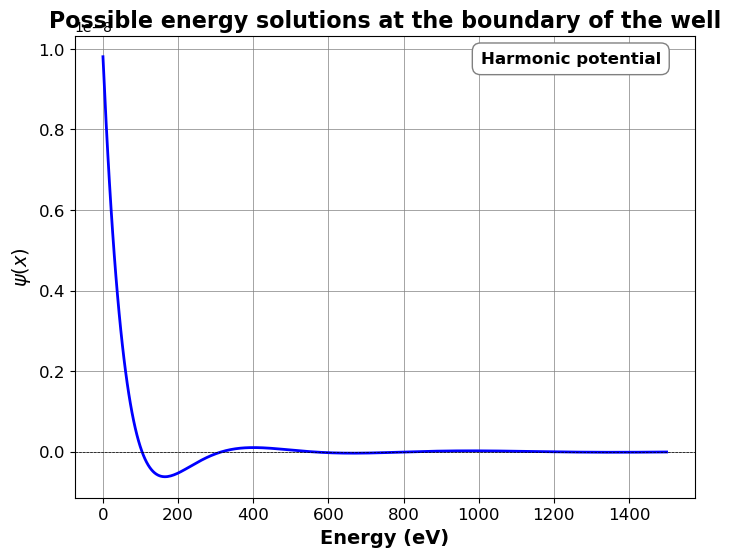

```
Energy guesses ; possible energy solutions:
 Energy Level  Energy Guess 1  Energy Guess 2
          1.0      105.300860      109.598854
          2.0      311.690544      324.412607
          3.0      543.352436      565.530086
          4.0      817.134670      850.487106
```

```python
# Calculate new energy guesses with a harmonic potential
V_NEW = new_V(x_points)  # Create a harmonic potential
new_potential_guess = energy_calculator(energy_array_II, frame_levels_II, energy_values_II, V_NEW)  # Calculate new energy guesses

# Plot the points at which there is indication of an energy level
fig, ax = plt.subplots(figsize=(8, 6))  # Create a figure with a custom size
ax.plot(energy_values_II, new_potential_guess[1], color='blue', linewidth=2)  # Plot energy values against corresponding phi values
ax.set_xlabel("Energy (eV)", fontsize=14, fontweight='bold')  # Add X-axis label with custom font size and weight
ax.set_ylabel("$\psi(x)$", fontsize=14, fontweight='bold')  # Add Y-axis label with custom font size and weight
ax.set_title("Possible energy solutions at the boundary of the well", fontsize=16, fontweight='bold')  # Add plot title with custom font size and weight
ax.grid(True, color='gray', linestyle='-', linewidth=0.5)  # Add grid lines to the plot with custom color, linestyle, and linewidth
ax.tick_params(axis='both', which='major', labelsize=12)  # Set tick label font size
ax.axhline(y=0, color='black', linestyle='--', linewidth=0.5)  # Add a horizontal line at y=0 with custom color, linestyle, and linewidth
ax.text(0.8, 0.95, "Harmonic potential", transform=ax.transAxes, fontsize=12, fontweight='bold', ha='center', va='center', bbox=dict(facecolor='white', edgecolor='gray', boxstyle='round,pad=0.5'))  # Add a text box with custom font size, weight, position, and background color
plt.show()  # Show the plot

# Output the energy guesses in a data frame
print("Energy guesses ; possible energy solutions:")
print(new_potential_guess[0].data.to_string(index=False))  # Output energy guesses without row index
```

```python
#old block:2

well_class2 = "Harmonic" # Setting well class to harmonic for energy_finder1() loop
Frame_levels3 = np.linspace(0,2,3) # Taking the first 3 energy levels
new_potential_energy = energy_finder1(Frame_levels3, V_NEW, new_potential_guess[2],energy_values_II,well_class2) # Finding the enrgies for the energy levels
new_potential_energy[0] # Outputting as a data frame
```

Pandas dataframe showing energy values output from energy_finder1() function

| N(level) | Predicted / eV | Calculated (eV) | Difference (eV) |
| --- | --- | --- | --- |
| 1.000000 | 103.285768 | 103.918605 | 0.632837 |
| 2.000000 | 309.857305 | 317.008801 | 7.151496 |
| 3.000000 | 516.428841 | 551.873355 | 35.444515 |

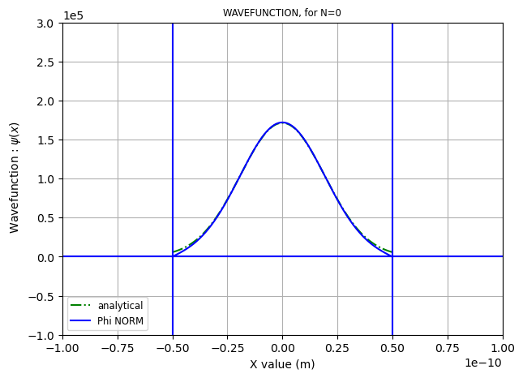

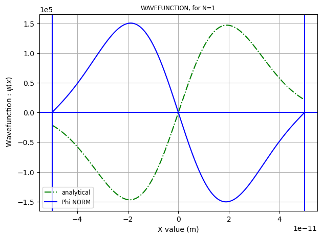

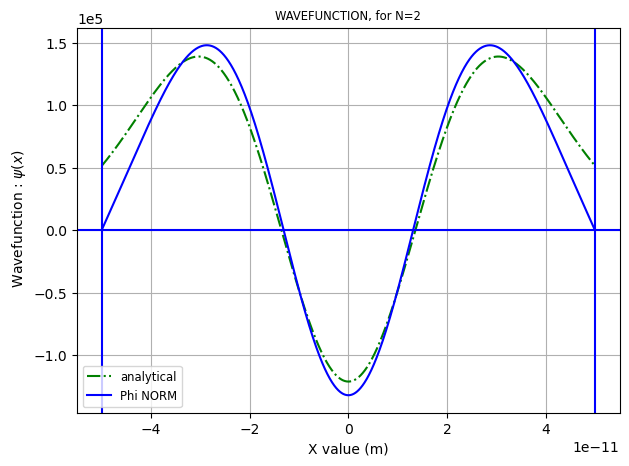

```python
#nunu block:0.5


#NEW BLOCK--> 0.5
well_class2 = "Harmonic" # Setting well class to harmonic for energy_finder1() loop
Frame_levels3 = np.linspace(0, 2, 3) # Taking the first 3 energy levels
new_potential_energy = energy_finder1(Frame_levels3, V_NEW, new_potential_guess[2], energy_values_II, well_class2) # Finding the energies for the energy levels
new_potential_energy[0] # Outputting as a data frame

Energy_sols2 = new_potential_energy[1]

# Creating the first plot
plt.figure(figsize=(7, 5))
# Plotting the numerical and theoretical wavefunctions for the first energy level
calcplot(Energy_sols2[0], x_points2, 0, V_NEW, well_class2)
plt.title("WAVEFUNCTION, for N=0", fontsize='small')
plt.grid(True)
plt.xlim(-10e-11, 10e-11)
plt.ylim(-1e5, 3e5)

# Creating the second plot
plt.figure(figsize=(7, 5))
# Plotting the numerical and theoretical wavefunctions for the second energy level
calcplot(Energy_sols2[1], x_points2, 1, V_NEW, well_class2)
plt.title("WAVEFUNCTION, for N=1", fontsize='small')
plt.grid(True)

# Creating the third plot
plt.figure(figsize=(7, 5))
# Plotting the numerical and theoretical wavefunctions for the third energy level
calcplot(Energy_sols2[2], x_points2, 2, V_NEW, well_class2)
plt.title("WAVEFUNCTION, for N=2", fontsize='small')
plt.grid(True)


#the 3 lowest eigenstatees
```

[figure not shown]

[figure not shown]

[figure not shown]

[figure not shown]

```python
# Plotting the harmonic potential and the first 4 energy levels:


# plot the harmonic potential energy and the first eigenlevel energy value
fig, ax = plt.subplots(figsize=(8, 6))
ax.plot(x_points, V_NEW, color='black', label='Potential energy line')
ax.plot(x_points2, [Energy_sols2[0]]*len(x_points2), color='red', label='First eigenlevel energy value')
ax.set_xlim([-10e-11, 10e-11])
ax.axvline(x=x_start, c='grey', linestyle='--', label='Well potential boundaries')
ax.axvline(x=x_end, c='grey', linestyle='--')
ax.axhline(y=0, c='black', linewidth=0.5)
ax.fill_between(x_points, V_NEW, alpha=0.2, color='black')
ax.grid(color='grey', alpha=0.3)
ax.set_xlabel('x position (m)')
ax.set_ylabel('Energy (eV)')
ax.set_title('Energy solutions for a harmonic potential')
ax.legend(loc='upper right')
plt.show()

# plot the harmonic potential energy and the second eigenlevel energy value
fig, ax = plt.subplots(figsize=(8, 6))
ax.plot(x_points, V_NEW, color='black', label='Potential energy line')
ax.plot(x_points2, [Energy_sols2[1]]*len(x_points2), color='orange', label='Second eigenlevel energy value')
ax.set_xlim([-10e-11, 10e-11])
ax.axvline(x=x_start, c='grey', linestyle='--', label='Well potential boundaries')
ax.axvline(x=x_end, c='grey', linestyle='--')
ax.axhline(y=0, c='black', linewidth=0.5)
ax.fill_between(x_points, V_NEW, alpha=0.2, color='black')
ax.grid(color='grey', alpha=0.3)
ax.set_xlabel('x position (m)')
ax.set_ylabel('Energy (eV)')
ax.set_title('Energy solutions for a harmonic potential')
ax.legend(loc='upper right')
plt.show()

# plot the harmonic potential energy and the third eigenlevel energy value
fig, ax = plt.subplots(figsize=(8, 6))
ax.plot(x_points, V_NEW, color='black', label='Potential energy line')
ax.plot(x_points2, [Energy_sols2[2]]*len(x_points2), color='green', label='Third eigenlevel energy value')
ax.set_xlim([-10e-11, 10e-11])
ax.axvline(x=x_start, c='grey', linestyle='--', label='Well potential boundaries')
ax.axvline(x=x_end, c='grey', linestyle='--')
ax.axhline(y=0, c='black', linewidth=0.5)
ax.fill_between(x_points, V_NEW, alpha=0.2, color='black')
ax.grid(color='grey', alpha=0.3)
ax.set_xlabel('x position (m)')
ax.set_ylabel('Energy (eV)')
ax.set_title('Energy solutions for a harmonic potential')
ax.legend(loc='upper right')
plt.show()


# plot the harmonic potential energy and the first 4 energy levels
fig, ax = plt.subplots(figsize=(8, 6))
ax.plot(x_points, V_NEW, color='black', label='Potential energy line')
ax.plot(x_points2, [Energy_sols2[0]]*len(x_points2), color='red', label='first eigenlevel energy value')
ax.plot(x_points2, [Energy_sols2[1]]*len(x_points2), color='orange', label='second eigenlevel energy value')
ax.plot(x_points2, [Energy_sols2[2]]*len(x_points2), color='green', label='potential wall bounds')

#DISPLAYING ALL levels on one plot

ax.set_xlim([-10e-11, 10e-11])
ax.axvline(x=x_start, c='grey', linestyle='--', label='Well potential boundaries')
ax.axvline(x=x_end, c='grey', linestyle='--')
ax.axhline(y=0, c='black', linewidth=0.5)
ax.grid(color='blue', alpha=0.3)
ax.set_xlabel('x position (m)')
ax.set_ylabel('Energy (eV)')
ax.set_title('Energy solutions for a harmonic potential')
ax.legend(loc='upper right')
plt.show()
```

```python
#Finite square Well
```

```python
def V_coc(init_pot, xvals, sizewall):  #single well potential (ref:double well potential)

    """
    Calculates the potential energy for a finite square well.

    Inputs:
    V02: float, initial value of the potential
    x_points: array-like, range of x values to evaluate the potential across
    a: float, half the width of the well

    Outputs:
    V_2: array-like, potential energy values evaluated at each x value
    """
    pot_arr = []  # initialize the potential energy array with empty array pot_arr
    for p in xvals:
        if abs(p) <= sizewall/2:  # limit for the potential
            x = 0  # potential is 0 within the well
        else:
            x = init_pot
        pot_arr.append(x)  # append the solution to the empty array pot_arr
    return pot_arr  # potential array
```

```python
pots = V_coc(potential_V0_finite,x_points,half_width) # The finite well potential
```

```python
#calculating energies for this potential
```